# Hospital Readmission Case Study

## Introduction

Hospital readmissions within 30 days of discharge are a significant concern for healthcare systems, as they often indicate a gap in patient care and contribute to increased healthcare costs. The objective of this project is to develop a predictive model that can identify patients at high risk of readmission. Such a tool can enable hospitals to implement targeted interventions, like enhanced post-discharge follow-up, to reduce readmission rates.

## Dataset information

The dataset used is a simplified version of a dataset sourced from the UCI Machine Learning repository. UCI Repository Link: https://archive.ics.uci.edu/dataset/296/diabetes+130-us+hospitals+for+years+1999-2008

Kaggle Link: https://www.kaggle.com/datasets/dubradave/hospital-readmissions/data

Data Source and Acknowledgment

- Data was sourced from the UCI Machine Learning Repository and Kaggle.
- All patient data has been anonymized to ensure privacy and compliance with ethical data usage practices.

## Data Dictionary

- "age" - age bracket of the patient
- "time_in_hospital" - days (from 1 to 14)
- "n_procedures" - number of procedures performed during the hospital stay
- "n_lab_procedures" - number of laboratory procedures performed during the hospital stay
- "n_medications" - number of medications administered during the hospital stay
- "n_outpatient" - number of outpatient visits in the year before a hospital stay
- "n_inpatient" - number of inpatient visits in the year before the hospital stay
- "n_emergency" - number of visits to the emergency room in the year before the hospital stay
- "medical_specialty" - the specialty of the admitting physician
- "diag_1" - primary diagnosis (Circulatory, Respiratory, Digestive, etc.)
- "diag_2" - secondary diagnosis
- "diag_3" - additional secondary diagnosis
- "glucose_test" - whether the glucose serum came out as high (> 200), normal, or not performed
- "A1Ctest" - whether the A1C level of the patient came out as high (> 7%), normal, or not performed
- "change" - whether there was a change in the diabetes medication ('yes' or 'no')
- "diabetes_med" - whether a diabetes medication was prescribed ('yes' or 'no')
- "readmitted" - if the patient was readmitted at the hospital ('yes' or 'no')

## Libraries

```python
import pandas as pd
import numpy as np
import matplotlib.pyplot as plt
import seaborn as sns
%matplotlib inline

import warnings
warnings.filterwarnings('ignore')

import math
from scipy.stats import uniform

pd.options.display.max_colwidth = 100
pd.set_option('display.max_columns', None)

from numpy.random import seed
seed(42)

from sklearn.model_selection import train_test_split, RandomizedSearchCV, \
    GridSearchCV, cross_val_score, StratifiedKFold, KFold
from sklearn.ensemble import RandomForestClassifier, GradientBoostingClassifier, AdaBoostClassifier, \
    GradientBoostingRegressor, RandomForestRegressor, AdaBoostRegressor, IsolationForest
from sklearn.svm import OneClassSVM
from sklearn.tree import DecisionTreeClassifier, DecisionTreeRegressor
from sklearn.linear_model import LogisticRegression, LinearRegression
from sklearn.decomposition import PCA
from sklearn.pipeline import make_pipeline, Pipeline
from sklearn.preprocessing import LabelEncoder, StandardScaler, MinMaxScaler
from sklearn.metrics import confusion_matrix, accuracy_score, precision_score,\
    recall_score, f1_score, roc_auc_score, ConfusionMatrixDisplay, roc_curve, auc, classification_report, \
    mean_absolute_error, r2_score, mean_squared_error
```

## Data

```python
df = pd.read_csv('../Data/hospital_readmissions.csv')
df.head()
```

|  | age | time_in_hospital | n_lab_procedures | n_procedures | n_medications | n_outpatient | n_inpatient | n_emergency | medical_specialty | diag_1 | diag_2 | diag_3 | glucose_test | A1Ctest | change | diabetes_med | readmitted |
| --- | --- | --- | --- | --- | --- | --- | --- | --- | --- | --- | --- | --- | --- | --- | --- | --- | --- |
| 0 | [70-80) | 8 | 72 | 1 | 18 | 2 | 0 | 0 | Missing | Circulatory | Respiratory | Other | no | no | no | yes | no |
| 1 | [70-80) | 3 | 34 | 2 | 13 | 0 | 0 | 0 | Other | Other | Other | Other | no | no | no | yes | no |
| 2 | [50-60) | 5 | 45 | 0 | 18 | 0 | 0 | 0 | Missing | Circulatory | Circulatory | Circulatory | no | no | yes | yes | yes |
| 3 | [70-80) | 2 | 36 | 0 | 12 | 1 | 0 | 0 | Missing | Circulatory | Other | Diabetes | no | no | yes | yes | yes |
| 4 | [60-70) | 1 | 42 | 0 | 7 | 0 | 0 | 0 | InternalMedicine | Other | Circulatory | Respiratory | no | no | no | yes | no |

```python
# formating age
df['age'] = df['age'].str.replace('[','(',regex=False)
df.head()
```

|  | age | time_in_hospital | n_lab_procedures | n_procedures | n_medications | n_outpatient | n_inpatient | n_emergency | medical_specialty | diag_1 | diag_2 | diag_3 | glucose_test | A1Ctest | change | diabetes_med | readmitted |
| --- | --- | --- | --- | --- | --- | --- | --- | --- | --- | --- | --- | --- | --- | --- | --- | --- | --- |
| 0 | (70-80) | 8 | 72 | 1 | 18 | 2 | 0 | 0 | Missing | Circulatory | Respiratory | Other | no | no | no | yes | no |
| 1 | (70-80) | 3 | 34 | 2 | 13 | 0 | 0 | 0 | Other | Other | Other | Other | no | no | no | yes | no |
| 2 | (50-60) | 5 | 45 | 0 | 18 | 0 | 0 | 0 | Missing | Circulatory | Circulatory | Circulatory | no | no | yes | yes | yes |
| 3 | (70-80) | 2 | 36 | 0 | 12 | 1 | 0 | 0 | Missing | Circulatory | Other | Diabetes | no | no | yes | yes | yes |
| 4 | (60-70) | 1 | 42 | 0 | 7 | 0 | 0 | 0 | InternalMedicine | Other | Circulatory | Respiratory | no | no | no | yes | no |

## Exploratory Data Analysis

```python
df.shape
```

```
(25000, 17)
```

```python
df.info()
```

```
<class 'pandas.core.frame.DataFrame'>
RangeIndex: 25000 entries, 0 to 24999
Data columns (total 17 columns):
 #   Column             Non-Null Count  Dtype
---  ------             --------------  -----
 0   age                25000 non-null  object
 1   time_in_hospital   25000 non-null  int64
 2   n_lab_procedures   25000 non-null  int64
 3   n_procedures       25000 non-null  int64
 4   n_medications      25000 non-null  int64
 5   n_outpatient       25000 non-null  int64
 6   n_inpatient        25000 non-null  int64
 7   n_emergency        25000 non-null  int64
 8   medical_specialty  25000 non-null  object
 9   diag_1             25000 non-null  object
 10  diag_2             25000 non-null  object
 11  diag_3             25000 non-null  object
 12  glucose_test       25000 non-null  object
 13  A1Ctest            25000 non-null  object
 14  change             25000 non-null  object
 15  diabetes_med       25000 non-null  object
 16  readmitted         25000 non-null  object
dtypes: int64(7), object(10)
memory usage: 3.2+ MB
```

```python
df.isnull().sum()
```

```
age                  0
time_in_hospital     0
n_lab_procedures     0
n_procedures         0
n_medications        0
n_outpatient         0
n_inpatient          0
n_emergency          0
medical_specialty    0
diag_1               0
diag_2               0
diag_3               0
glucose_test         0
A1Ctest              0
change               0
diabetes_med         0
readmitted           0
dtype: int64
```

```python
# Numerical
numerical_features = df.select_dtypes(exclude='object').columns
numerical_features
```

```
Index(['time_in_hospital', 'n_lab_procedures', 'n_procedures', 'n_medications',
       'n_outpatient', 'n_inpatient', 'n_emergency'],
      dtype='object')
```

```python
df.describe()
```

|  | time_in_hospital | n_lab_procedures | n_procedures | n_medications | n_outpatient | n_inpatient | n_emergency |
| --- | --- | --- | --- | --- | --- | --- | --- |
| count | 25000.00000 | 25000.00000 | 25000.000000 | 25000.000000 | 25000.000000 | 25000.000000 | 25000.000000 |
| mean | 4.45332 | 43.24076 | 1.352360 | 16.252400 | 0.366400 | 0.615960 | 0.186600 |
| std | 3.00147 | 19.81862 | 1.715179 | 8.060532 | 1.195478 | 1.177951 | 0.885873 |
| min | 1.00000 | 1.00000 | 0.000000 | 1.000000 | 0.000000 | 0.000000 | 0.000000 |
| 25% | 2.00000 | 31.00000 | 0.000000 | 11.000000 | 0.000000 | 0.000000 | 0.000000 |
| 50% | 4.00000 | 44.00000 | 1.000000 | 15.000000 | 0.000000 | 0.000000 | 0.000000 |
| 75% | 6.00000 | 57.00000 | 2.000000 | 20.000000 | 0.000000 | 1.000000 | 0.000000 |
| max | 14.00000 | 113.00000 | 6.000000 | 79.000000 | 33.000000 | 15.000000 | 64.000000 |

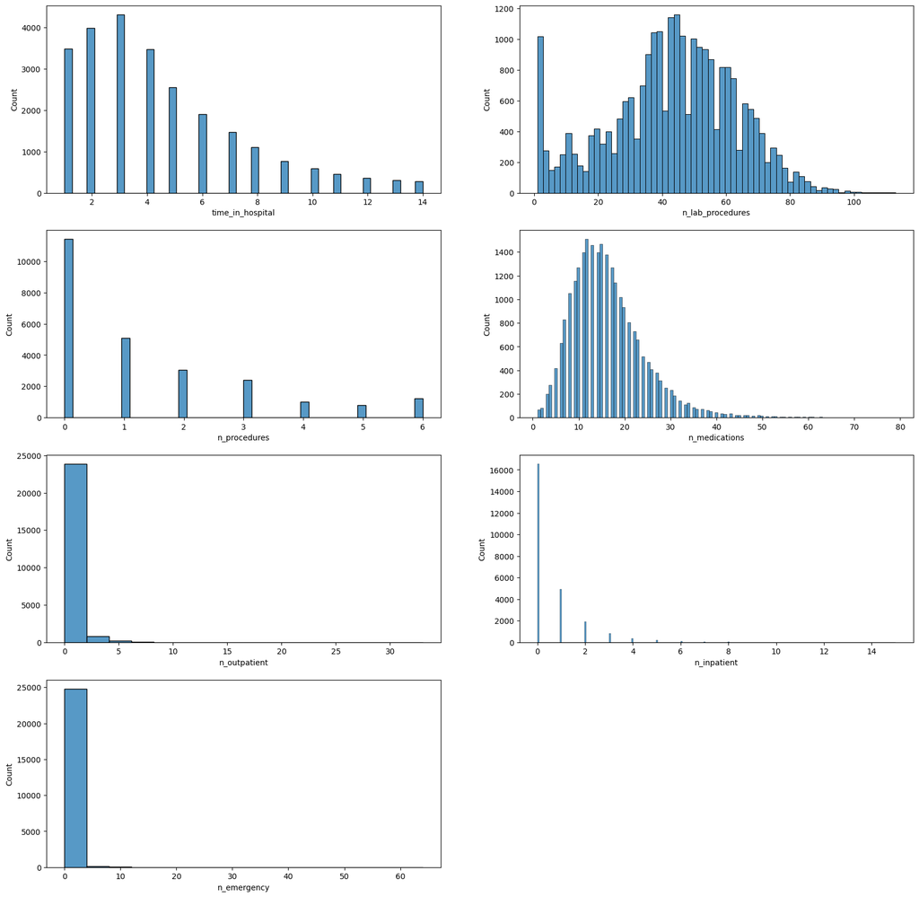

```python
plt.figure(figsize = (20, 20))

plt.subplot(4, 2, 1)
sns.histplot(x = df['time_in_hospital'], kde = False)

plt.subplot(4, 2, 2)
sns.histplot(x = df['n_lab_procedures'], kde = False)

plt.subplot(4, 2, 3)
sns.histplot(x = df['n_procedures'], kde = False)

plt.subplot(4, 2, 4)
sns.histplot(x = df['n_medications'], kde = False)

plt.subplot(4, 2, 5)
sns.histplot(x = df['n_outpatient'], kde = False)

plt.subplot(4, 2, 6)
sns.histplot(x = df['n_inpatient'], kde = False)

plt.subplot(4, 2, 7)
sns.histplot(x = df['n_emergency'], kde = False)
```

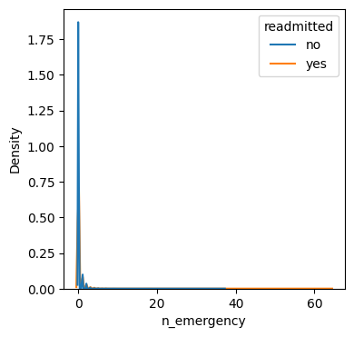

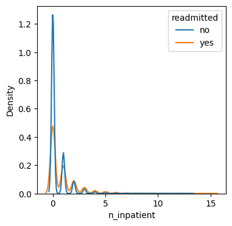

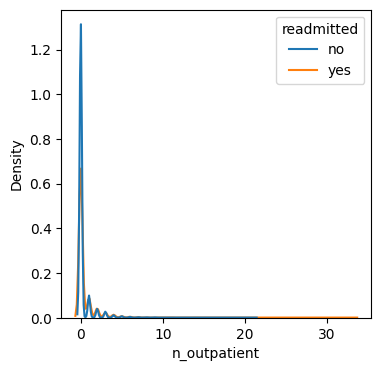

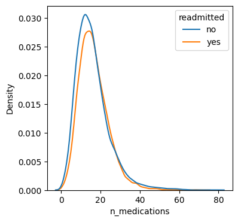

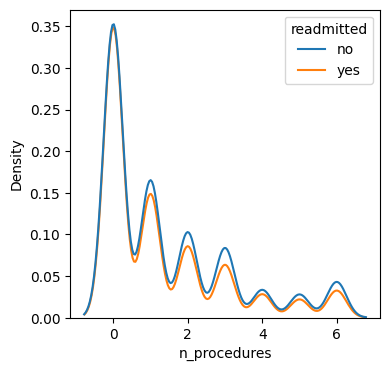

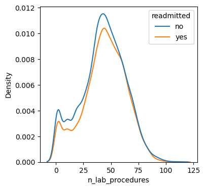

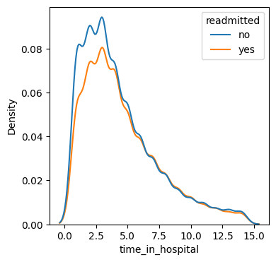

```python
# KDE plots
num_feat = numerical_features[::-1]
for feature in num_feat:
    plt.figure(figsize=(4,4))
    sns.kdeplot(data=df, x=feature, hue='readmitted')
    plt.show()
```

Several attributes are positively skewed and need to be transformed.

```python
df['n_inpatient'].value_counts()
```

```
n_inpatient
0     16537
1      4926
2      1909
3       833
4       358
5       211
6       104
7        47
8        26
9        20
10       12
11        8
12        3
14        2
15        2
13        2
Name: count, dtype: int64
```

```python
df['n_emergency'].value_counts()
```

```
n_emergency
0     22272
1      1842
2       525
3       167
4        83
5        40
7        18
6        18
9         6
8         6
10        6
18        3
11        3
12        2
16        2
19        2
28        1
37        1
21        1
13        1
64        1
Name: count, dtype: int64
```

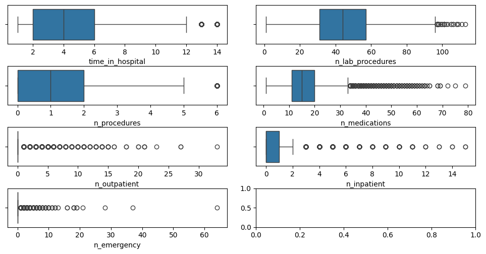

```python
plt.subplots_adjust(hspace=0.3, wspace = 0.7)
fig, axs = plt.subplots(4, 2, figsize=(10, 5))
fig.tight_layout()

sns.boxplot(data = df, x = 'time_in_hospital', ax = axs[0, 0])
sns.boxplot(data = df, x = 'n_lab_procedures', ax = axs[0, 1])
sns.boxplot(data = df, x = 'n_procedures', ax = axs[1, 0])
sns.boxplot(data = df, x = 'n_medications', ax = axs[1, 1])
sns.boxplot(data = df, x = 'n_outpatient', ax = axs[2, 0])
sns.boxplot(data = df, x = 'n_inpatient', ax = axs[2, 1])
sns.boxplot(data = df, x = 'n_emergency', ax = axs[3, 0])

plt.show()
```

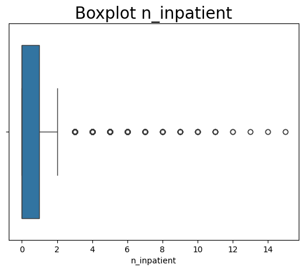

```python
plt.title("Boxplot n_inpatient", fontdict = {'fontsize': 20})
sns.boxplot(x=df["n_inpatient"])
```

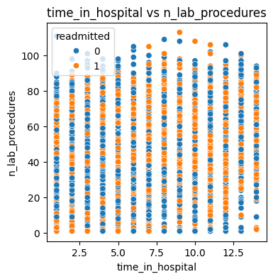

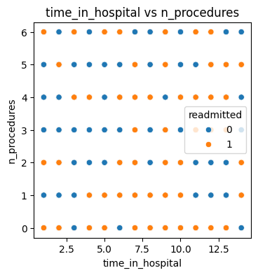

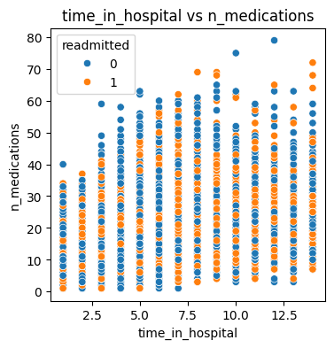

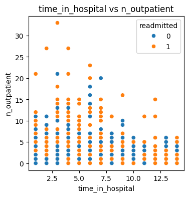

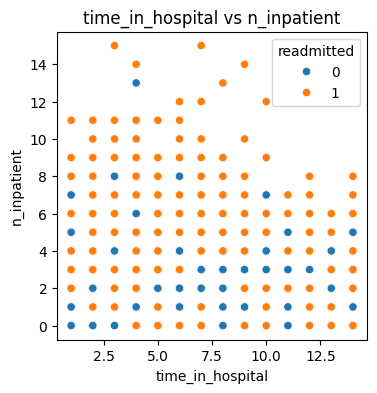

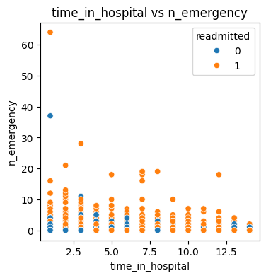

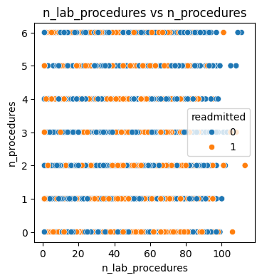

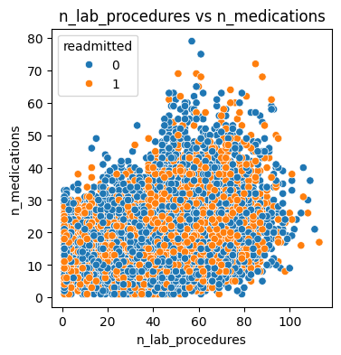

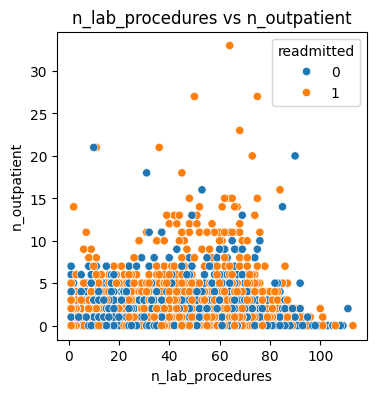

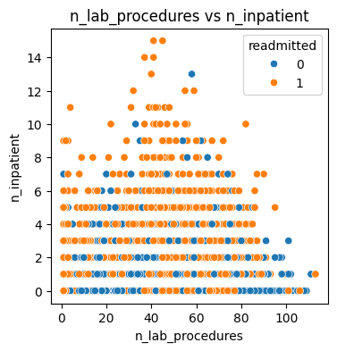

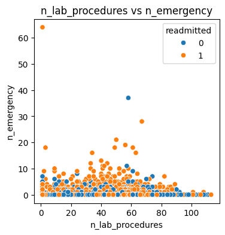

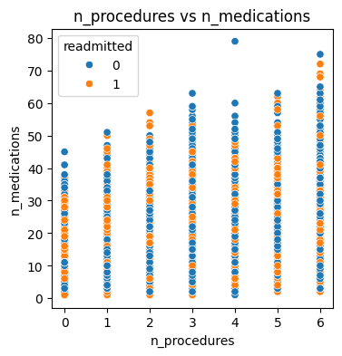

[9 more figures not shown]

```python
# scatter plot

def check_pair(pair, pair_dict):
    f1, f2 = pair
    # If f1 already has f2 recorded or vice versa → duplicate
    if f1 in pair_dict and f2 in pair_dict[f1]:
        return False
    if f2 in pair_dict and f1 in pair_dict[f2]:
        return False
    return True

def append_pair(pair, pair_dict):
    f1, f2 = pair
    pair_dict.setdefault(f1, []).append(f2)
    pair_dict.setdefault(f2, []).append(f1)

pair_dict = dict()

for f1 in numerical_features:
  for f2 in numerical_features:
    if f1 == f2:
      continue
    else:
      pair = (f1, f2)
      if check_pair(pair, pair_dict):
        append_pair(pair, pair_dict)
        plt.figure(figsize=(4,4))
        sns.scatterplot(data=df, x=f1, y=f2, hue='readmitted')
        plt.title(f'{f1} vs {f2}')
        plt.show()
```

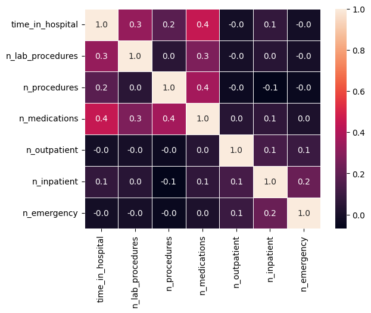

```python
sns.heatmap(df[numerical_features].corr(), annot=True, linewidth=.5, fmt=".1f")
```

```python
# categorical
df.select_dtypes(include = 'object').describe()
```

|  | age | medical_specialty | diag_1 | diag_2 | diag_3 | glucose_test | A1Ctest | change | diabetes_med | readmitted |
| --- | --- | --- | --- | --- | --- | --- | --- | --- | --- | --- |
| count | 25000 | 25000 | 25000 | 25000 | 25000 | 25000 | 25000 | 25000 | 25000 | 25000 |
| unique | 6 | 7 | 8 | 8 | 8 | 3 | 3 | 2 | 2 | 2 |
| top | (70-80) | Missing | Circulatory | Other | Other | no | no | no | yes | no |
| freq | 6837 | 12382 | 7824 | 9056 | 9107 | 23625 | 20938 | 13497 | 19228 | 13246 |

```python
df.select_dtypes(include='object').columns
```

```
Index(['age', 'medical_specialty', 'diag_1', 'diag_2', 'diag_3',
       'glucose_test', 'A1Ctest', 'change', 'diabetes_med', 'readmitted'],
      dtype='object')
```

```python
categorical_features = df.select_dtypes(include='object').columns
for i in categorical_features:
    print(i,':',df[i].unique())
```

```
age : ['(70-80)' '(50-60)' '(60-70)' '(40-50)' '(80-90)' '(90-100)']
medical_specialty : ['Missing' 'Other' 'InternalMedicine' 'Family/GeneralPractice'
 'Cardiology' 'Surgery' 'Emergency/Trauma']
diag_1 : ['Circulatory' 'Other' 'Injury' 'Digestive' 'Respiratory' 'Diabetes'
 'Musculoskeletal' 'Missing']
diag_2 : ['Respiratory' 'Other' 'Circulatory' 'Injury' 'Diabetes' 'Digestive'
 'Musculoskeletal' 'Missing']
diag_3 : ['Other' 'Circulatory' 'Diabetes' 'Respiratory' 'Injury' 'Musculoskeletal'
 'Digestive' 'Missing']
glucose_test : ['no' 'normal' 'high']
A1Ctest : ['no' 'normal' 'high']
change : ['no' 'yes']
diabetes_med : ['yes' 'no']
readmitted : ['no' 'yes']
```

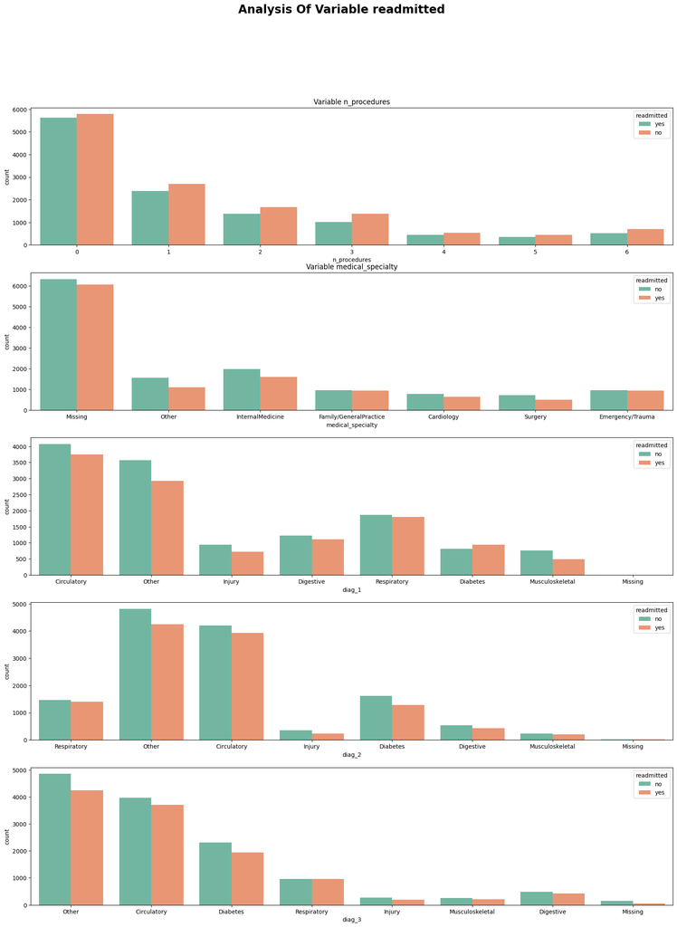

```python
plt.figure(figsize = (20, 25))
plt.suptitle("Analysis Of Variable readmitted",fontweight="bold", fontsize=20)

plt.subplot(5, 1, 1)
plt.gca().set_title('Variable n_procedures')
sns.countplot(x = 'n_procedures', hue = 'readmitted', palette = 'Set2', data = df)

plt.subplot(5, 1, 2)
plt.gca().set_title('Variable medical_specialty')
sns.countplot(x = 'medical_specialty', hue = 'readmitted', palette = 'Set2', data = df)

plt.subplot(5, 1, 3)
sns.countplot(x = 'diag_1', hue = 'readmitted', palette = 'Set2', data = df)

plt.subplot(5, 1, 4)
sns.countplot(x = 'diag_2', hue = 'readmitted', palette = 'Set2', data = df)

plt.subplot(5, 1, 5)
sns.countplot(x = 'diag_3', hue = 'readmitted', palette = 'Set2', data = df)
```

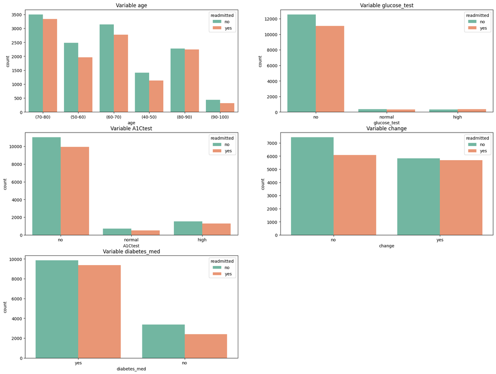

```python
plt.figure(figsize = (20, 15))

plt.subplot(3, 2, 1)
plt.gca().set_title('Variable age')
sns.countplot(x = 'age', hue = 'readmitted', palette = 'Set2', data = df)

plt.subplot(3, 2, 2)
plt.gca().set_title('Variable glucose_test')
sns.countplot(x = 'glucose_test', hue = 'readmitted', palette = 'Set2', data = df)

plt.subplot(3, 2, 3)
plt.gca().set_title('Variable A1Ctest')
sns.countplot(x = 'A1Ctest', hue = 'readmitted', palette = 'Set2', data = df)

plt.subplot(3, 2, 4)
plt.gca().set_title('Variable change')
sns.countplot(x = 'change', hue = 'readmitted', palette = 'Set2', data = df)

plt.subplot(3, 2, 5)
plt.gca().set_title('Variable diabetes_med')
sns.countplot(x = 'diabetes_med', hue = 'readmitted',  palette = 'Set2', data = df)
```

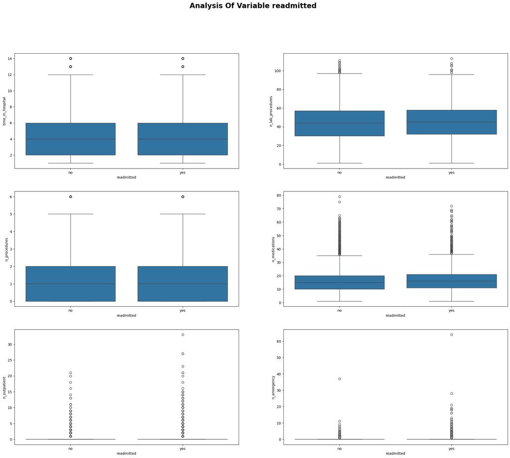

```python
plt.figure(figsize = (25, 20))
plt.suptitle("Analysis Of Variable readmitted",fontweight="bold", fontsize=20)

plt.subplot(3,2,1)
sns.boxplot(x="readmitted", y="time_in_hospital", data=df)

plt.subplot(3,2,2)
sns.boxplot(x="readmitted", y="n_lab_procedures", data=df)

plt.subplot(3,2,3)
sns.boxplot(x="readmitted", y="n_procedures", data=df)

plt.subplot(3,2,4)
sns.boxplot(x="readmitted", y="n_medications", data=df)

plt.subplot(3,2,5)
sns.boxplot(x="readmitted", y="n_outpatient", data=df)

plt.subplot(3,2,6)
sns.boxplot(x="readmitted", y="n_emergency", data=df)
```

```python
df['diag_1'].value_counts() / df.shape[0]
```

```
diag_1
Circulatory        0.31296
Other              0.25992
Respiratory        0.14720
Digestive          0.09316
Diabetes           0.06988
Injury             0.06664
Musculoskeletal    0.05008
Missing            0.00016
Name: count, dtype: float64
```

```python
df['diag_2'].value_counts() / df.shape[0]
```

```
diag_2
Other              0.36224
Circulatory        0.32536
Diabetes           0.11624
Respiratory        0.11488
Digestive          0.03892
Injury             0.02364
Musculoskeletal    0.01704
Missing            0.00168
Name: count, dtype: float64
```

```python
df['diag_3'].value_counts() / df.shape[0]
```

```
diag_3
Other              0.36428
Circulatory        0.30744
Diabetes           0.17044
Respiratory        0.07660
Digestive          0.03664
Injury             0.01856
Musculoskeletal    0.01820
Missing            0.00784
Name: count, dtype: float64
```

```python
categorical_features
```

```
Index(['age', 'medical_specialty', 'diag_1', 'diag_2', 'diag_3',
       'glucose_test', 'A1Ctest', 'change', 'diabetes_med', 'readmitted'],
      dtype='object')
```

```python
binaryCols = ['change','diabetes_med','readmitted']
for i in binaryCols:
    df[i] = df[i].apply(lambda x: 0 if x == 'no' else 1)

noNormalHighCols = ['glucose_test','A1Ctest']
for i in noNormalHighCols:
    df[i] = df[i].apply(lambda x: 0 if x == 'no' else 1 if x == 'normal' else 2)


def label_encode_cat_features(data, cat_features):
    label_encoder = LabelEncoder()
    data_encoded = data.copy()

    for col in cat_features:
        data_encoded[col] = label_encoder.fit_transform(data[col])

    data = data_encoded
    return data

col_cat = ['age', 'medical_specialty', 'diag_1', 'diag_2', 'diag_3']
df = label_encode_cat_features(df, col_cat)

df.head()
```

|  | age | time_in_hospital | n_lab_procedures | n_procedures | n_medications | n_outpatient | n_inpatient | n_emergency | medical_specialty | diag_1 | diag_2 | diag_3 | glucose_test | A1Ctest | change | diabetes_med | readmitted |
| --- | --- | --- | --- | --- | --- | --- | --- | --- | --- | --- | --- | --- | --- | --- | --- | --- | --- |
| 0 | 3 | 8 | 72 | 1 | 18 | 2 | 0 | 0 | 4 | 0 | 7 | 6 | 0 | 0 | 0 | 1 | 0 |
| 1 | 3 | 3 | 34 | 2 | 13 | 0 | 0 | 0 | 5 | 6 | 6 | 6 | 0 | 0 | 0 | 1 | 0 |
| 2 | 1 | 5 | 45 | 0 | 18 | 0 | 0 | 0 | 4 | 0 | 0 | 0 | 0 | 0 | 1 | 1 | 1 |
| 3 | 3 | 2 | 36 | 0 | 12 | 1 | 0 | 0 | 4 | 0 | 6 | 1 | 0 | 0 | 1 | 1 | 1 |
| 4 | 2 | 1 | 42 | 0 | 7 | 0 | 0 | 0 | 3 | 6 | 0 | 7 | 0 | 0 | 0 | 1 | 0 |

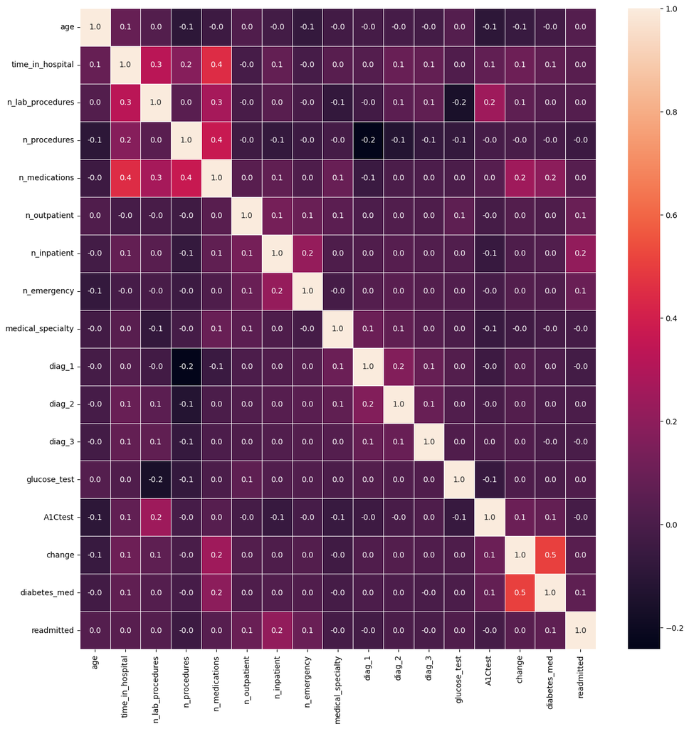

```python
# Correlation matrix
plt.figure(figsize=(15,15))
sns.heatmap(df.corr(), annot=True, linewidth=.5, fmt=".1f")
```

```python
df['readmitted'].value_counts() / df.shape[0]
```

```
readmitted
0    0.52984
1    0.47016
Name: count, dtype: float64
```

```python
quantCols = df.select_dtypes(include=[int,float]).columns
df_features = df[quantCols]
df_features.head()
```

|  | age | time_in_hospital | n_lab_procedures | n_procedures | n_medications | n_outpatient | n_inpatient | n_emergency | medical_specialty | diag_1 | diag_2 | diag_3 | glucose_test | A1Ctest | change | diabetes_med | readmitted |
| --- | --- | --- | --- | --- | --- | --- | --- | --- | --- | --- | --- | --- | --- | --- | --- | --- | --- |
| 0 | 3 | 8 | 72 | 1 | 18 | 2 | 0 | 0 | 4 | 0 | 7 | 6 | 0 | 0 | 0 | 1 | 0 |
| 1 | 3 | 3 | 34 | 2 | 13 | 0 | 0 | 0 | 5 | 6 | 6 | 6 | 0 | 0 | 0 | 1 | 0 |
| 2 | 1 | 5 | 45 | 0 | 18 | 0 | 0 | 0 | 4 | 0 | 0 | 0 | 0 | 0 | 1 | 1 | 1 |
| 3 | 3 | 2 | 36 | 0 | 12 | 1 | 0 | 0 | 4 | 0 | 6 | 1 | 0 | 0 | 1 | 1 | 1 |
| 4 | 2 | 1 | 42 | 0 | 7 | 0 | 0 | 0 | 3 | 6 | 0 | 7 | 0 | 0 | 0 | 1 | 0 |

```python
#Transforming all colimns that have noticeable skewness
transformCols = [
    'time_in_hospital','n_lab_procedures','n_procedures',
    'n_medications','n_outpatient','n_inpatient','n_emergency'
]

# checking if all column datatype is numeric
all([pd.api.types.is_numeric_dtype(df_features[col]) for col in transformCols])
```

```
True
```

```python
# Perform a log transformation of the data to unskew the data
df_sqrt = np.sqrt(df_features)

#Check how many INF readings we have in the data
np.isinf(df_sqrt).sum()
```

```
age                  0
time_in_hospital     0
n_lab_procedures     0
n_procedures         0
n_medications        0
n_outpatient         0
n_inpatient          0
n_emergency          0
medical_specialty    0
diag_1               0
diag_2               0
diag_3               0
glucose_test         0
A1Ctest              0
change               0
diabetes_med         0
readmitted           0
dtype: int64
```

```python
#Change INF values to mean for each feature
for i in transformCols:
    df_sqrt[i].replace([np.inf, -np.inf], np.nan, inplace=True)
    df_sqrt[i] = df_sqrt[i].fillna(df_sqrt[i].mean())

np.isinf(df_sqrt).sum()
```

```
age                  0
time_in_hospital     0
n_lab_procedures     0
n_procedures         0
n_medications        0
n_outpatient         0
n_inpatient          0
n_emergency          0
medical_specialty    0
diag_1               0
diag_2               0
diag_3               0
glucose_test         0
A1Ctest              0
change               0
diabetes_med         0
readmitted           0
dtype: int64
```

```python
df_sqrt.shape
```

```
(25000, 17)
```

```python
df_sqrt.head()
```

|  | age | time_in_hospital | n_lab_procedures | n_procedures | n_medications | n_outpatient | n_inpatient | n_emergency | medical_specialty | diag_1 | diag_2 | diag_3 | glucose_test | A1Ctest | change | diabetes_med | readmitted |
| --- | --- | --- | --- | --- | --- | --- | --- | --- | --- | --- | --- | --- | --- | --- | --- | --- | --- |
| 0 | 1.732051 | 2.828427 | 8.485281 | 1.000000 | 4.242641 | 1.414214 | 0.0 | 0.0 | 2.000000 | 0.00000 | 2.645751 | 2.449490 | 0.0 | 0.0 | 0.0 | 1.0 | 0.0 |
| 1 | 1.732051 | 1.732051 | 5.830952 | 1.414214 | 3.605551 | 0.000000 | 0.0 | 0.0 | 2.236068 | 2.44949 | 2.449490 | 2.449490 | 0.0 | 0.0 | 0.0 | 1.0 | 0.0 |
| 2 | 1.000000 | 2.236068 | 6.708204 | 0.000000 | 4.242641 | 0.000000 | 0.0 | 0.0 | 2.000000 | 0.00000 | 0.000000 | 0.000000 | 0.0 | 0.0 | 1.0 | 1.0 | 1.0 |
| 3 | 1.732051 | 1.414214 | 6.000000 | 0.000000 | 3.464102 | 1.000000 | 0.0 | 0.0 | 2.000000 | 0.00000 | 2.449490 | 1.000000 | 0.0 | 0.0 | 1.0 | 1.0 | 1.0 |
| 4 | 1.414214 | 1.000000 | 6.480741 | 0.000000 | 2.645751 | 0.000000 | 0.0 | 0.0 | 1.732051 | 2.44949 | 0.000000 | 2.645751 | 0.0 | 0.0 | 0.0 | 1.0 | 0.0 |

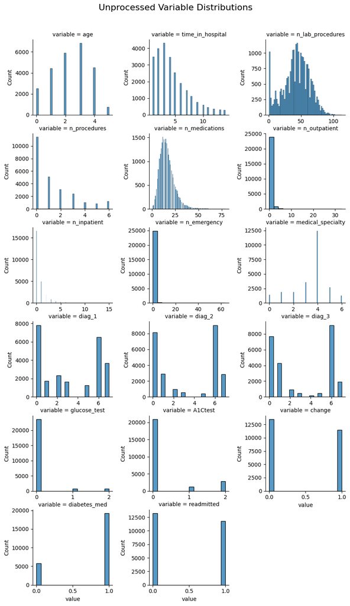

```python
g = sns.FacetGrid(
    df_features.melt(),
    col='variable',
    sharey=False,
    sharex=False,
    col_wrap = 3
)

g.map(sns.histplot, "value")
g.figure.subplots_adjust(top=0.8)
g.figure.suptitle("Unprocessed Variable Distributions", fontsize=16,y=.85)
plt.show()
```

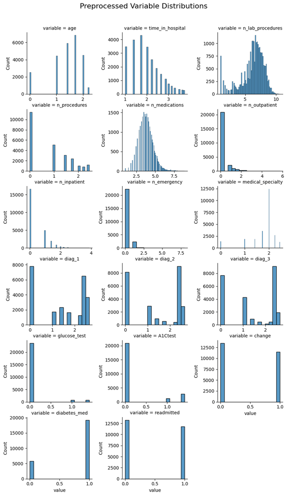

```python
df_sqrt['readmitted'] = df_features['readmitted']

g = sns.FacetGrid(
    df_sqrt.melt(),
    col="variable",
    col_wrap = 3,
    sharey=False,
    sharex=False
)
g.map(sns.histplot, "value")
g.figure.subplots_adjust(top=0.8)
g.figure.suptitle("Preprocessed Variable Distributions", fontsize=16,y=.85)
plt.show()
```

## Model for Re-admission Classification

The following models are being compared for the classification task:

- Logistic Regression: A fundamental linear model that calculates the probability of a binary outcome. It serves as a strong baseline for classification problems.
- Decision Tree Classifier: A non-linear model that makes predictions by following a tree-like structure of decisions. It is easy to interpret but can be prone to overfitting.
- Random Forest Classifier: An ensemble model that builds multiple decision trees and averages their predictions to improve accuracy and reduce overfitting.
- Gradient Boosting Classifier: A powerful ensemble technique that builds a series of weak models sequentially. Each new model corrects the errors of its predecessor, leading to a highly accurate final model.
- AdaBoost Classifier: Another ensemble method that focuses on misclassified samples from previous iterations, giving them higher weight to improve the final model's performance.

Performance metrics:Accuracy, Precision, Recall, F1 score, ROC-AUC score and confusion metrics

```python
df.head()
```

|  | age | time_in_hospital | n_lab_procedures | n_procedures | n_medications | n_outpatient | n_inpatient | n_emergency | medical_specialty | diag_1 | diag_2 | diag_3 | glucose_test | A1Ctest | change | diabetes_med | readmitted |
| --- | --- | --- | --- | --- | --- | --- | --- | --- | --- | --- | --- | --- | --- | --- | --- | --- | --- |
| 0 | 3 | 8 | 72 | 1 | 18 | 2 | 0 | 0 | 4 | 0 | 7 | 6 | 0 | 0 | 0 | 1 | 0 |
| 1 | 3 | 3 | 34 | 2 | 13 | 0 | 0 | 0 | 5 | 6 | 6 | 6 | 0 | 0 | 0 | 1 | 0 |
| 2 | 1 | 5 | 45 | 0 | 18 | 0 | 0 | 0 | 4 | 0 | 0 | 0 | 0 | 0 | 1 | 1 | 1 |
| 3 | 3 | 2 | 36 | 0 | 12 | 1 | 0 | 0 | 4 | 0 | 6 | 1 | 0 | 0 | 1 | 1 | 1 |
| 4 | 2 | 1 | 42 | 0 | 7 | 0 | 0 | 0 | 3 | 6 | 0 | 7 | 0 | 0 | 0 | 1 | 0 |

```python
df_sqrt.head()
```

|  | age | time_in_hospital | n_lab_procedures | n_procedures | n_medications | n_outpatient | n_inpatient | n_emergency | medical_specialty | diag_1 | diag_2 | diag_3 | glucose_test | A1Ctest | change | diabetes_med | readmitted |
| --- | --- | --- | --- | --- | --- | --- | --- | --- | --- | --- | --- | --- | --- | --- | --- | --- | --- |
| 0 | 1.732051 | 2.828427 | 8.485281 | 1.000000 | 4.242641 | 1.414214 | 0.0 | 0.0 | 2.000000 | 0.00000 | 2.645751 | 2.449490 | 0.0 | 0.0 | 0.0 | 1.0 | 0 |
| 1 | 1.732051 | 1.732051 | 5.830952 | 1.414214 | 3.605551 | 0.000000 | 0.0 | 0.0 | 2.236068 | 2.44949 | 2.449490 | 2.449490 | 0.0 | 0.0 | 0.0 | 1.0 | 0 |
| 2 | 1.000000 | 2.236068 | 6.708204 | 0.000000 | 4.242641 | 0.000000 | 0.0 | 0.0 | 2.000000 | 0.00000 | 0.000000 | 0.000000 | 0.0 | 0.0 | 1.0 | 1.0 | 1 |
| 3 | 1.732051 | 1.414214 | 6.000000 | 0.000000 | 3.464102 | 1.000000 | 0.0 | 0.0 | 2.000000 | 0.00000 | 2.449490 | 1.000000 | 0.0 | 0.0 | 1.0 | 1.0 | 1 |
| 4 | 1.414214 | 1.000000 | 6.480741 | 0.000000 | 2.645751 | 0.000000 | 0.0 | 0.0 | 1.732051 | 2.44949 | 0.000000 | 2.645751 | 0.0 | 0.0 | 0.0 | 1.0 | 0 |

```python
X = df.drop(columns=['readmitted'], axis=1)
X_processed = df_sqrt.drop(columns=['readmitted'], axis=1)
y = df_sqrt['readmitted']

X.shape, X_processed.shape, y.shape
```

```
((25000, 16), (25000, 16), (25000,))
```

```python
seed = 42
# train test split
X_train, X_test, y_train, y_test = train_test_split(
    X, y, test_size=0.10, random_state=seed)

X_train_processed, X_test_processed, y_train_processed, y_test_processed = train_test_split(
    X_processed, y, test_size=0.10, random_state=seed)

X_train.shape, X_test.shape, X_train_processed.shape, X_test_processed.shape
```

```
((22500, 16), (2500, 16), (22500, 16), (2500, 16))
```

```python
# Performing PCA to reduce the dimensionality of the dataset
pca = PCA(n_components=None)
pipeline = make_pipeline(StandardScaler(), pca)

# Fit on train, transform both
X_train_trans = pipeline.fit_transform(X_train)
X_test_trans  = pipeline.transform(X_test)

X_train_trans_processed = pipeline.fit_transform(X_train_processed)
X_test_trans_processed  = pipeline.transform(X_test_processed)

X_train_trans.shape, X_train_trans_processed.shape
```

```
((22500, 16), (22500, 16))
```

```python
def roc_auc_display(test_result, model_name):
    plt.figure(figsize=(4,4))
    for name in model_name:
        fpr, tpr, _ = roc_curve(test_result['y_test'], test_result[name] )
        roc_auc = auc(fpr, tpr)
        plt.plot(fpr, tpr, label=f'{name} (AUC = {roc_auc:.2f})')

    plt.plot([0, 1], [0, 1], 'r--', label='Random Guess')
    plt.xlabel('False Positive Rate')
    plt.ylabel('True Positive Rate')
    plt.title('ROC Curves for Two Models')
    plt.legend()
    plt.show()

def evaluate_model_classifer(model_list, model_name, X_train, y_train, X_test, y_test):
    pred_log = {'y_test': y_test}
    model_dict = {}
    results_list = []

    for model, name in zip(model_list, model_name):
        # train & predict
        model_base = model
        model_base.fit(X_train, y_train)
        y_pred = model_base.predict(X_test)

        # save predictions and model
        pred_log[name] = y_pred
        model_dict[name] = model_base

        # compute metrics
        acc = accuracy_score(y_test, y_pred)
        prec = precision_score(y_test, y_pred)
        rec = recall_score(y_test, y_pred)
        f1 = f1_score(y_test, y_pred)
        roc = roc_auc_score(y_test, y_pred)
        cm = confusion_matrix(y_test, y_pred)

        # append to results list for DataFrame
        results_list.append({
            'Name': name,
            'Accuracy': acc,
            'Precision': prec,
            'Recall': rec,
            'F1 score': f1,
            'ROC_AUC': roc,
            'Confusion_Matrix': cm
        })

    # build DataFrame and print a rounded view for neat output
    results_df = pd.DataFrame(results_list)
    display_df = results_df.copy()
    numeric_cols = ['Accuracy', 'Precision', 'Recall', 'F1 score', 'ROC_AUC']
    display_df[numeric_cols] = display_df[numeric_cols].round(4)
    print(display_df.to_string(index=False))

    return pred_log, model_dict, results_df
```

```python
lr = LogisticRegression(tol=1e-4, max_iter=1000, random_state=seed)

space = dict(C=uniform(loc=0, scale=5),
                     penalty=['l2', 'l1'],
                     solver= ['liblinear'])

search = RandomizedSearchCV(lr,
                         space,
                         random_state=seed,
                         cv = 5,
                         scoring='f1')

rand_search = search.fit(X_train, y_train)
print('Best Hyperparameters: %s' % rand_search.best_params_)

params = rand_search.best_params_
lr = LogisticRegression(**params)
lr.fit(X_train, y_train)
print(classification_report(y_test, lr.predict(X_test)))
```

[output not shown]